# SDS322 Final Project

SDS322E

November 15, 2022

```r
library(dplyr)
library(ggplot2)
library(readr)
clean_train <- read_csv("~/SDS322E/sds322-final-project/clean_train.csv")
head(clean_train)
```

```
## # A tibble: 6 × 81
##      Id MSSubClass  MSZon…¹ LotFr…² LotArea Street Alley LotSh…³ LandC…⁴ Utili…⁵
##   <dbl> <chr>       <chr>     <dbl>   <dbl> <chr>  <chr>   <dbl> <chr>     <dbl>
## 1     1 2-STORY 19… RL           65    8450 Pave   <NA>        0 Lvl           3
## 2     2 1-STORY 19… RL           80    9600 Pave   <NA>        0 Lvl           3
## 3     3 2-STORY 19… RL           68   11250 Pave   <NA>        1 Lvl           3
## 4     4 2-STORY 19… RL           60    9550 Pave   <NA>        1 Lvl           3
## 5     5 2-STORY 19… RL           84   14260 Pave   <NA>        1 Lvl           3
## 6     6 1-1/2 STOR… RL           85   14115 Pave   <NA>        1 Lvl           3
## # … with 71 more variables: LotConfig <chr>, LandSlope <dbl>,
## #   Neighborhood <chr>, Condition1 <chr>, Condition2 <chr>, BldgType <chr>,
## #   HouseStyle <chr>, OverallQual <dbl>, OverallCond <dbl>, YearBuilt <dbl>,
## #   YearRemodAdd <dbl>, RoofStyle <chr>, RoofMatl <chr>, Exterior1st <chr>,
## #   Exterior2nd <chr>, MasVnrType <chr>, MasVnrArea <dbl>, ExterQual <dbl>,
## #   ExterCond <dbl>, Foundation <chr>, BsmtQual <dbl>, BsmtCond <dbl>,
## #   BsmtExposure <dbl>, BsmtFinType1 <dbl>, BsmtFinSF1 <dbl>, …
```

## Project:

Identifying trends between home attributes and the sales price of the homes to approximate what variables have the most impact on the sales price and which can be used to predict sales price. Our goal is to create a model that can take attributes of homes as inputs and accurately predict what the sales price will be.

## Goals:

Find which factors appear to most greatly affect the sales price of a home. Once these factors are found, explore the predictive power the factors have on sales price and whether they can be used to accurately predict the sales price of a home.

## Link to data:

https://www.kaggle.com/datasets/rsizem2/house-prices-ames-cleaned-dataset?select=new_train.csv

## References:

The Ames Housing dataset was compiled by Dean De Cock for use in data science education. link: http://www.amstat.org/publications/jse/v19n3/decock.pdf

## Histogram of SalePrice (dependent variable):

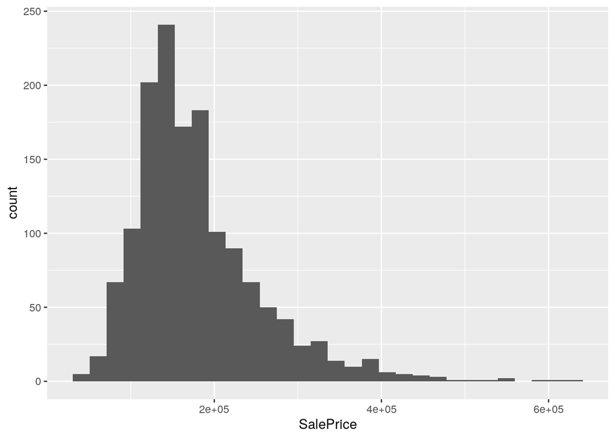

```r
clean_train %>%
    ggplot(aes(x = SalePrice)) + geom_histogram()
```

```r
head(clean_train)
```

```
## # A tibble: 6 × 81
##      Id MSSubClass  MSZon…¹ LotFr…² LotArea Street Alley LotSh…³ LandC…⁴ Utili…⁵
##   <dbl> <chr>       <chr>     <dbl>   <dbl> <chr>  <chr>   <dbl> <chr>     <dbl>
## 1     1 2-STORY 19… RL           65    8450 Pave   <NA>        0 Lvl           3
## 2     2 1-STORY 19… RL           80    9600 Pave   <NA>        0 Lvl           3
## 3     3 2-STORY 19… RL           68   11250 Pave   <NA>        1 Lvl           3
## 4     4 2-STORY 19… RL           60    9550 Pave   <NA>        1 Lvl           3
## 5     5 2-STORY 19… RL           84   14260 Pave   <NA>        1 Lvl           3
## 6     6 1-1/2 STOR… RL           85   14115 Pave   <NA>        1 Lvl           3
## # … with 71 more variables: LotConfig <chr>, LandSlope <dbl>,
## #   Neighborhood <chr>, Condition1 <chr>, Condition2 <chr>, BldgType <chr>,
## #   HouseStyle <chr>, OverallQual <dbl>, OverallCond <dbl>, YearBuilt <dbl>,
## #   YearRemodAdd <dbl>, RoofStyle <chr>, RoofMatl <chr>, Exterior1st <chr>,
## #   Exterior2nd <chr>, MasVnrType <chr>, MasVnrArea <dbl>, ExterQual <dbl>,
## #   ExterCond <dbl>, Foundation <chr>, BsmtQual <dbl>, BsmtCond <dbl>,
## #   BsmtExposure <dbl>, BsmtFinType1 <dbl>, BsmtFinSF1 <dbl>, …
```

```r
# install.packages('corrplot') library(corrplot)
# clean_train_numeric_only <-
# select_if(clean_train, is.numeric) res <-
# cor(clean_train_numeric_only) corrplot(res,
# type = 'upper', order = 'hclust', tl.col =
# 'black', tl.srt = 45)
```

[output not shown]

[output not shown]